# Walking through PUMS, survey and survyr

Nick Chun

2018-01-08

# About Me

- Demographer at PSU
- Oregon Population Forecast Program
- Intermediate User of R and PUMS

# What is PUMS?

- Public Use Microdata Sample (PUMS)
- Results from [ACS](https://www2.census.gov/programs-surveys/acs/methodology/questionnaires/2018/quest18.pdf) respondents
- Contains person-level and housing-level characteristics
- Data aggregated to Public Use Microdata Areas (PUMA)
- Contains at least 100,000 people
- Built from Census Tracts, but does not necessarily nest within Counties

# Portland MSA

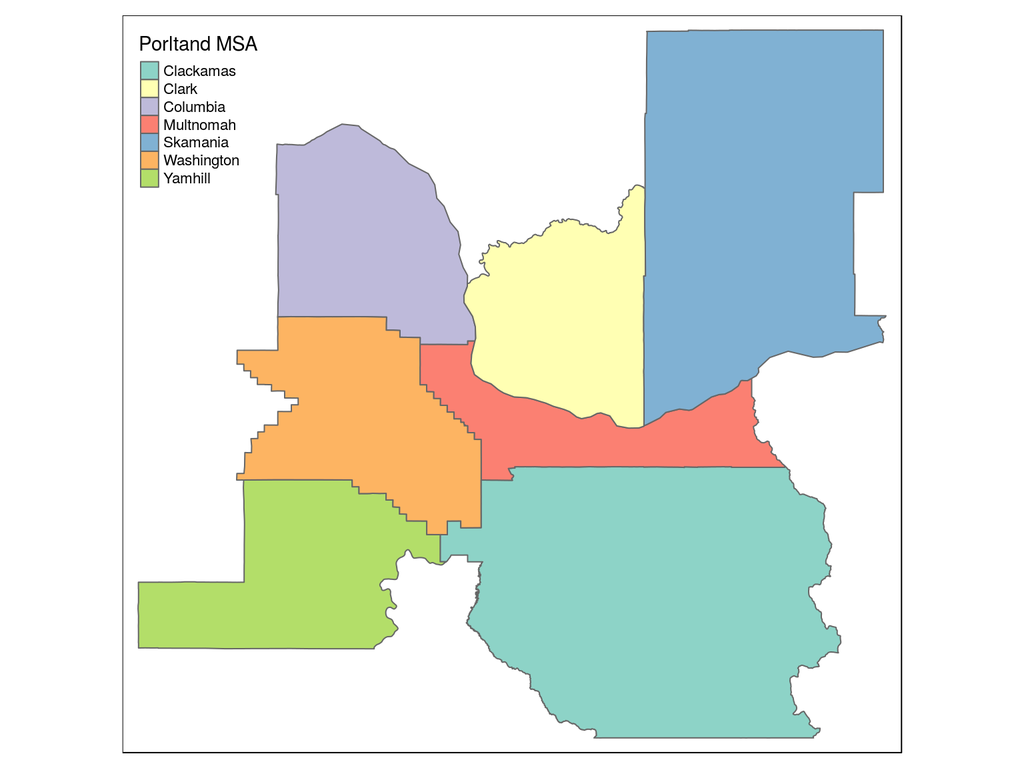

# Portland MSA PUMAs

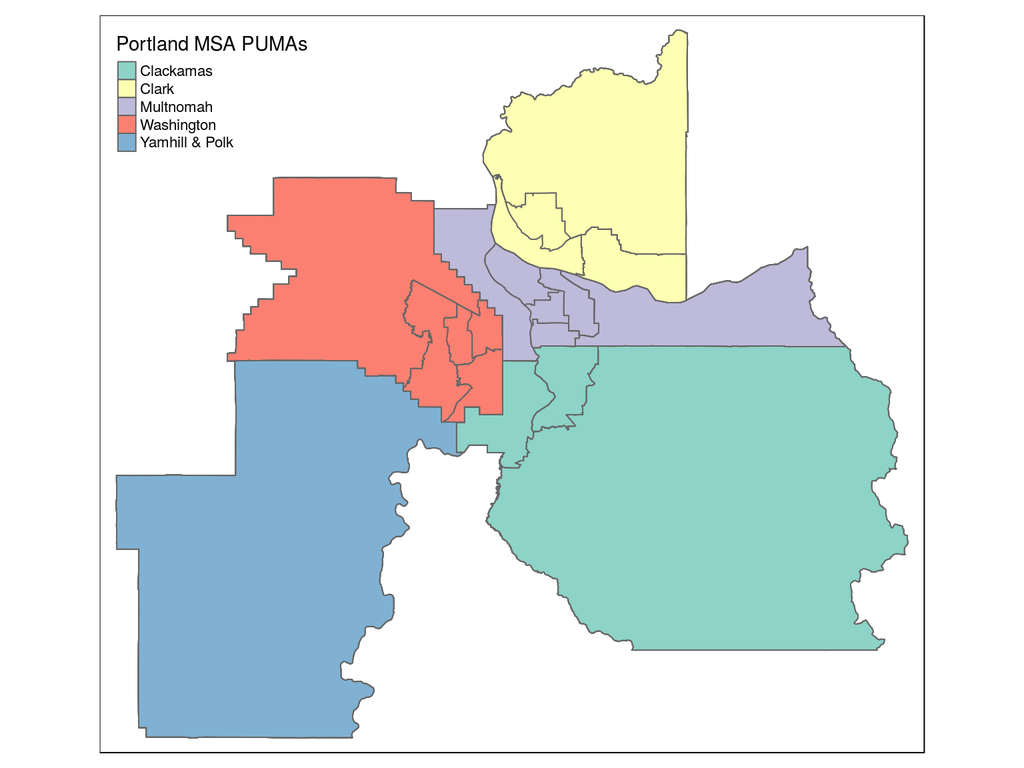

# PUMS comparison to ACS

- 1 and 5 year tables
- ACS tables are summaries of PUMS data
- PUMS data have a smaller sample size: 1% vs ~1.5%
- Anonymized
- Uses
  - Custom Tables
  - Sample Weights
  - Modeling

# Example: Number of Children (<1) by Household Size and Ethnicity For the Tri-County area

| hisp_class | hh_n | estimate | moe | share | share_moe | cv | share_cv |
| --- | --- | --- | --- | --- | --- | --- | --- |
| Hispanic | hh size <=4 | 2218 | 1251.0 | 60.0 | 21.3 | 0.34 | 0.36 |
| Hispanic | hh size >4 | 1480 | 1032.6 | 40.0 | 21.7 | 0.42 | 0.54 |
| Not Hispanic | hh size <=4 | 10064 | 1765.4 | 69.3 | 6.0 | 0.11 | 0.09 |
| Not Hispanic | hh size >4 | 4468 | 1345.6 | 30.7 | 8.0 | 0.18 | 0.26 |

# Example: Code (Design)

```r
query<-or_pums %>% mutate(hisp_boolean= case_when(hisp>1 & agep==0~ "Hispanic", TRUE~ "Not Hispanic")) %>%
  group_by(serialno) %>% mutate(ncount=n()) %>% ungroup() %>%
  mutate(hh_n = case_when(ncount>4~"hh size >4", TRUE ~ "hh size <=4"))%>%
  filter(grepl(paste(tri_filter$PUMACE10,collapse = "|"),puma_p), agep==0,type==1)

x<-svrepdesign(weights= ~pwgtp,
               repweights = 'pwgtp[0-9]+',
               scale=4/80,
               rscales = ncol('pwgtp[0-9]+'),
               mse=T,
               combined.weights = T,
               type='JK1',
               data= query)

output<-svyby(~hisp_boolean,~hh_n,x,svytotal,na.rm=T)
```

# Example: Code (Clean Up & Output)

```r
output<- output %>% as.data.frame(.) %>%
  rename(Hispanic=hisp_booleanHispanic,`Not Hispanic`=`hisp_booleanNot Hispanic`,hisp_se=se1,n_hisp_se=se2)
rownames(output)<-1:2

output<-cbind(output %>% select(1:3) %>% gather(hisp_class,estimate,2:3),
              output %>% select(1,4,5) %>% gather(hisp_class,se,2:3)%>%
                select(3)) %>%
  mutate(cv=round(se/estimate,2),moe=round(se*1.645,1)) %>%
  group_by(hisp_class) %>%
  mutate(total=sum(estimate),total_moe=round(moe_sum(moe,estimate),1)) %>%
  ungroup() %>%
  mutate(share=round(100*estimate/total,1), share_moe=round(100*moe_prop(estimate,total,moe,total_moe),1), share_cv=round(share_moe/share,2)) %>%
  select(hisp_class,hh_n,estimate,moe,share,share_moe,cv,share_cv)%>% arrange(hisp_class,hh_n)
```

| hisp_class | hh_n | estimate | moe | share | share_moe | cv | share_cv |
| --- | --- | --- | --- | --- | --- | --- | --- |
| Hispanic | hh size <=4 | 2218 | 1251.0 | 60.0 | 21.3 | 0.34 | 0.36 |
| Hispanic | hh size >4 | 1480 | 1032.6 | 40.0 | 21.7 | 0.42 | 0.54 |
| Not Hispanic | hh size <=4 | 10064 | 1765.4 | 69.3 | 6.0 | 0.11 | 0.09 |
| Not Hispanic | hh size >4 | 4468 | 1345.6 | 30.7 | 8.0 | 0.18 | 0.26 |

# Downloading PUMS Data

- [IPUMS](https://www.ipums.org)

- Download person and housing tables by state from the [Census](https://www.census.gov/programs-surveys/acs/data/pums.html)

```r
if(!require(pacman)){install.packages("pacman");library(pacman)}
p_load(tidyverse,data.table,survey,srvyr)


#String Variables are brought in as factors
options(stringsAsFactors = T)
#Variances are centered around the estimate rather than the mean of the replicate weights
options(survey.replicates.mse = T)
#Remove Scientific Notation
options(scipen = 999)
#Number of printed digits
options(digits = 2)
#fread creates data.frames instead of data.tables
options(datatable.fread.datatable=F)
#Clear environment
rm(list=ls())
```

# Downloading PUMS Data (Continued)

```r
#Set Working Directory

#Read Oregon 2016 1 yr housing unit records
or_h <- fread("ss16hor.csv",colClasses = c("SERIALNO"="character","PUMA"="character","ST"="character"))

#Conver column names to lower case
colnames(or_h)<-tolower(colnames(or_h))

#Read person level records and convert column names to lower case
or_p<-fread("ss16por.csv",colClasses = c("SERIALNO"="character","PUMA"="character", "MIGSP"="character", "ST"="character"))
colnames(or_p)<-tolower(colnames(or_p))
```

[Technical Documentation](https://www.census.gov/programs-surveys/acs/technical-documentation/pums/documentation.html):

- Data Dictionary: Detailed information about the attributes
- Estimates for User Verification: Check your results against these numbers to make sure you are calculating the estimates and sampling error correctly.

# PUMS Table Structure (Housing Unit)

Primary Key: serialno (housing unit id)

Household Weight: wgtp

ten: owned (1 & 2), rented(3 &4), gq/vacant (n/a)

noc: number of own children in household

hincp: household income

grpip: gross rent as percentage of hh income

ocpip: owner housing costs as percentage of hh income

```r
kable(or_h[1:5,] %>% select(serialno,puma,ten,noc,hincp,grpip,ocpip,wgtp))
```

| serialno | puma | ten | noc | hincp | grpip | ocpip | wgtp |
| --- | --- | --- | --- | --- | --- | --- | --- |
| 000000044 | 00600 | 1 | 0 | 59701 | NA | 14 | 15 |
| 000000086 | 00800 | 2 | 0 | 34500 | NA | 15 | 101 |
| 000000262 | 01200 | 1 | 0 | 62500 | NA | 21 | 102 |
| 000000271 | 00901 | 1 | 1 | 33000 | NA | 30 | 89 |
| 000000366 | 01321 | 3 | 0 | 68500 | 22 | NA | 24 |

# PUMS Table Structure (Person)

Primary Key: serialno (housing unit id) & sporder (person number)

Person Weight: pwgtp

sex: Male (1) and Female (2)

rac1p: Race code

hisp: Hispanic origin

hicov: with health insurance (1) and without health insurance (2)

migsp: state or country code one migrated from 1 year ago.

```r
kable(or_p[1:5,] %>% select(serialno,sporder,puma,pwgtp,agep,sex,rac1p,hisp,hicov,migsp))
```

| serialno | sporder | puma | pwgtp | agep | sex | rac1p | hisp | hicov | migsp |
| --- | --- | --- | --- | --- | --- | --- | --- | --- | --- |
| 000000044 | 1 | 00600 | 15 | 71 | 2 | 1 | 1 | 1 |  |
| 000000044 | 2 | 00600 | 16 | 71 | 1 | 1 | 1 | 1 |  |
| 000000086 | 1 | 00800 | 102 | 82 | 1 | 1 | 1 | 1 |  |
| 000000086 | 2 | 00800 | 101 | 72 | 2 | 1 | 1 | 1 |  |
| 000000262 | 1 | 01200 | 102 | 66 | 1 | 1 | 1 | 1 |  |

# PUMS Table Structure (Replicate Weights)

- 80 weights used to create standard error estimates
- Painful to work with
- Necessary for custom tabulations

```r
#Combine person and housing unit tables
or_pums<-or_p %>% left_join(or_h, by="serialno", suffix=c("_p","_h"))
kable(or_pums %>% select(serialno,sporder,pwgtp,wgtp,pwgtp1,pwgtp2,wgtp1,wgtp2) %>% .[1:5,])
```

| serialno | sporder | pwgtp | wgtp | pwgtp1 | pwgtp2 | wgtp1 | wgtp2 |
| --- | --- | --- | --- | --- | --- | --- | --- |
| 000000044 | 1 | 15 | 15 | 13 | 13 | 13 | 13 |
| 000000044 | 2 | 16 | 15 | 14 | 15 | 13 | 13 |
| 000000086 | 1 | 102 | 101 | 94 | 183 | 93 | 183 |
| 000000086 | 2 | 101 | 101 | 111 | 186 | 93 | 183 |
| 000000262 | 1 | 102 | 102 | 187 | 101 | 187 | 101 |

# Cost Burdened Households by Race & Ethnicity

Create (*mutate*) race & ethnicity and cost burdened field using *case_when*

```r
#Add Race & Ethnicity and Cost Burdened Fields
or_pums<-or_pums%>%mutate(hisp_boolean= if_else(hisp==1,0,1),
                          race_hisp=factor(case_when(rac1p==1& hisp_boolean==0~"wa",
                                                 rac1p==2 & hisp_boolean==0~"black",
                                                 c(rac1p==3|rac1p==4|rac1p==5)& hisp_boolean==0~"ai_an",
                                                 rac1p==6& hisp_boolean==0~"asian",
                                                 rac1p==7& hisp_boolean==0~"nh_pi",
                                                 rac1p==8& hisp_boolean==0~"other",
                                                 rac1p==9& hisp_boolean==0~"multi",
                                                 hisp_boolean==1~"hisp"),
                                       levels=c("wa","black","ai_an","asian","nh_pi","other","multi","hisp")), burden=factor(case_when(ocpip>=30|grpip>=30~ "burdened", TRUE ~ "not burdened")))
```

# Check Results

```r
#Check Results
kable(or_pums %>% select(race_hisp,rac1p,hisp_boolean,burden,ocpip,grpip) %>% sample_n(.,10))
```

|  | race_hisp | rac1p | hisp_boolean | burden | ocpip | grpip |
| --- | --- | --- | --- | --- | --- | --- |
| 10481 | wa | 1 | 0 | burdened | NA | 73 |
| 32751 | wa | 1 | 0 | not burdened | NA | 27 |
| 19496 | asian | 6 | 0 | not burdened | 3 | NA |
| 26587 | wa | 1 | 0 | not burdened | 7 | NA |
| 174 | wa | 1 | 0 | not burdened | 19 | NA |
| 24587 | wa | 1 | 0 | not burdened | 13 | NA |
| 15080 | hisp | 1 | 1 | burdened | NA | 101 |
| 11599 | wa | 1 | 0 | not burdened | 3 | NA |
| 24926 | wa | 1 | 0 | not burdened | 7 | NA |
| 37864 | black | 2 | 0 | not burdened | 26 | NA |

# Survey Package (Set Survey Design: Person)

```r
#person-level survey design
p_design<-svrepdesign(weights= ~pwgtp,
               repweights = 'pwgtp[0-9]+',
               scale=4/80,
               rscales = ncol('pwgtp[0-9]+'),
               mse=T,
               combined.weights = T,
               type='JK1',
               data= or_pums)
```

# Survey Package (Set Survey Design: Housing Unit)

```r
#join race & ethnicity and cost burdened fields to housing unit table
h_join<-left_join(or_h, or_pums %>% filter(sporder==1) %>% select(serialno,race_hisp,burden),by="serialno")

#housing unit-level survey design
h_design<-svrepdesign(weights= ~wgtp,
               repweights = 'wgtp[0-9]+',
               scale=4/80,
               rscales = ncol('wgtp[0-9]+'),
               mse=T,
               combined.weights = T,
               type='JK1',
               data= h_join)
```

# Joining Person and Housing Unit Tables: WARNING

Filtering the Person table to only include the householder (sporder ==1) will remove duplicate household estimates

```r
kable(or_pums[1:10,] %>% select(serialno,sporder,hincp) %>% filter(sporder==1))
```

| serialno | sporder | hincp |
| --- | --- | --- |
| 000000044 | 1 | 59701 |
| 000000086 | 1 | 34500 |
| 000000262 | 1 | 62500 |
| 000000271 | 1 | 33000 |
| 000000366 | 1 | 68500 |

```r
kable(or_h[1:5,] %>% select(serialno,hincp))
```

[output not shown]

```r
nrow(or_p %>% filter(sporder==1))
```

```
## [1] 17985
```

```r
nrow(or_h)
```

```
## [1] 19115
```

# Joining Person and Housing Unit Tables: WARNING (Continued)

The estimates will be the same, but the standard errors will be inflated for the filtered person table (sporder==1)

```r
# Households by Tenure: Housing Unit Results
kable(hu_result)
```

|  | total | SE |
| --- | --- | --- |
| as.factor(ten)1 | 637722 | 6740 |
| as.factor(ten)2 | 331449 | 5156 |
| as.factor(ten)3 | 575449 | 7060 |
| as.factor(ten)4 | 27057 | 2051 |

```r
#Households by Tenure: Filtered Person Table Results
kable(pfilter_result)
```

|  | total | SE |
| --- | --- | --- |
| as.factor(ten)1 | 637722 | 9537 |
| as.factor(ten)2 | 331449 | 7287 |
| as.factor(ten)3 | 575449 | 9992 |
| as.factor(ten)4 | 27057 | 2901 |

# Survey Package (Calibrate Model)

Calibrate Survey Design to known estimates (User Verification)

```r
#Calculate total of vector "sex" from survey replicate design "p_design" and drop missing/null cases
kable(svytotal(~as.factor(sex),p_design,na.rm=T))
```

|  | total | SE |
| --- | --- | --- |
| as.factor(sex)1 | 2032558 | 3149 |
| as.factor(sex)2 | 2060907 | 3149 |

```r
kable(svytotal(~as.factor(ten),h_design,na.rm=T))
```

|  | total | SE |
| --- | --- | --- |
| as.factor(ten)1 | 637722 | 6740 |
| as.factor(ten)2 | 331449 | 5156 |
| as.factor(ten)3 | 575449 | 7060 |
| as.factor(ten)4 | 27057 | 2051 |

# Survey Package (Examples)

```r
# Population by Race and Ethnicity
kable(svytotal(~race_hisp,p_design,na.rm=T))
```

|  | total | SE |
| --- | --- | --- |
| race_hispwa | 3117131 | 1817 |
| race_hispblack | 73476 | 2699 |
| race_hispai_an | 38681 | 2293 |
| race_hispasian | 171350 | 3647 |
| race_hispnh_pi | 14991 | 1917 |
| race_hispother | 6703 | 1314 |
| race_hispmulti | 148615 | 4214 |
| race_hisphisp | 522518 | 1031 |

```r
# Household Count by Race and Ethnicity of the Householder
kable(svytotal(~race_hisp,h_design,na.rm=T))
```

|  | total | SE |
| --- | --- | --- |
| race_hispwa | 1305064 | 4046 |
| race_hispblack | 25155 | 1341 |
| race_hispai_an | 11853 | 1117 |
| race_hispasian | 56298 | 1914 |
| race_hispnh_pi | 3327 | 582 |
| race_hispother | 1854 | 483 |
| race_hispmulti | 41013 | 2339 |
| race_hisphisp | 127113 | 3115 |

# Survey Package (Calculate Cost Burdened HH by Race & Ethnicity)

```r
#Cost Burdened Households by Race & Ethnicity
kable(svyby(~burden,~race_hisp,h_design,svytotal,na.rm=T) %>% as.data.frame(.) %>%
        rename(burdened=burdenburdened,notburdened=`burdennot burdened`,burdened_se=se1,notburdened_se=se2) %>%
        select(race_hisp,burdened,burdened_se,notburdened, notburdened_se))
```

|  | race_hisp | burdened | burdened_se | notburdened | notburdened_se |
| --- | --- | --- | --- | --- | --- |
| wa | wa | 427740 | 6437 | 877324 | 6977 |
| black | black | 11701 | 1390 | 13454 | 1413 |
| ai_an | ai_an | 5514 | 829 | 6339 | 797 |
| asian | asian | 18126 | 1547 | 38172 | 1869 |
| nh_pi | nh_pi | 1284 | 466 | 2043 | 492 |
| other | other | 824 | 329 | 1030 | 354 |
| multi | multi | 16907 | 1486 | 24106 | 1892 |
| hisp | hisp | 51660 | 2699 | 75453 | 2517 |

# Survey Package (Household Income by Race & Ethnicity)

```r
#Median Household Income for Oregon
kable(svyquantile(~hincp,h_design,quantiles=.5,na.rm=T) %>% as.data.frame(.))
```

|  | quantiles | hincp.1 |
| --- | --- | --- |
| q0.5 | 56200 | 650 |

```r
#Median Household Income by Race & Ethnicity for Oregon
kable(svyby(~hincp,~race_hisp,h_design,svyquantile,quantiles=.5,na.rm=T) %>% as.data.frame(.) %>% rename(HH_inc=V1))
```

|  | race_hisp | HH_inc | se |
| --- | --- | --- | --- |
| wa | wa | 58525 | 750 |
| black | black | 35086 | 3498 |
| ai_an | ai_an | 32000 | 4124 |
| asian | asian | 70000 | 4127 |
| nh_pi | nh_pi | 58070 | 15988 |
| other | other | 52741 | 14570 |
| multi | multi | 47976 | 1966 |
| hisp | hisp | 44408 | 2000 |

# Survey Package (Regression)

```r
# Household Income regressed on Race & Ethnicity of Householder
model<-svyglm(hincp ~ race_hisp ,h_design)
stargazer(model, type="text")
```

```
##
## =============================================
##                       Dependent variable:
##                   ---------------------------
##                              hincp
## ---------------------------------------------
## race_hispblack          -28,615.000***
##                           (3,695.000)
##
## race_hispai_an          -32,570.000***
##                           (4,011.000)
##
## race_hispasian           26,631.000***
##                           (5,568.000)
##
## race_hispnh_pi           -17,335.000*
##                           (8,792.000)
##
## race_hispother            -11,172.000
##                          (15,621.000)
##
## race_hispmulti          -14,272.000***
##                           (3,500.000)
##
## race_hisphisp           -20,225.000***
##                           (2,267.000)
##
## Constant                 78,277.000***
##                            (630.000)
##
## ---------------------------------------------
## Observations                16,198
## Log Likelihood           -206,651.000
## Akaike Inf. Crit.         413,318.000
## =============================================
## Note:             *p<0.1; **p<0.05; ***p<0.01
```

```r
1-model$deviance/model$null.deviance
```

```
## [1] 0.014
```

# survey vs srvyr package (workflow using survey)

```r
#Design
h_design<-svrepdesign(weights= ~wgtp,
               repweights = 'wgtp[0-9]+',
               scale=4/80,
               rscales = ncol('wgtp[0-9]+'),
               mse=T,
               combined.weights = T,
               type='JK1',
               data= h_join)

# Calculate Burdened and Not Burdened Households by Race & Ethnicity (Survey Package)
data_survey<-svyby(~burden,~race_hisp,h_design,svytotal,na.rm=T) %>% as.data.frame(.) %>%
 rename(burdened=burdenburdened,notburdened=`burdennot burdened`,burdened_se=se1,notburdened_se=se2) %>%
  select(race_hisp,burdened,burdened_se,notburdened, notburdened_se)

# Transform to Long Form
survey_output<- cbind(data_survey %>% select(race_hisp,burdened,notburdened) %>% gather(.,burden_class,estimate,2:3),
data_survey %>% select(race_hisp,burdened_se,notburdened_se) %>% gather(.,burden_class,se,2:3) %>% select(-1,-2)) %>%
  select(burden_class, race_hisp, estimate,se) %>% arrange(race_hisp,burden_class)
```

# survey vs srvyr package (workflow using survey continued)

```r
kable(survey_output)
```

| burden_class | race_hisp | estimate | se |
| --- | --- | --- | --- |
| burdened | wa | 427740 | 6437 |
| notburdened | wa | 877324 | 6977 |
| burdened | black | 11701 | 1390 |
| notburdened | black | 13454 | 1413 |
| burdened | ai_an | 5514 | 829 |
| notburdened | ai_an | 6339 | 797 |
| burdened | asian | 18126 | 1547 |
| notburdened | asian | 38172 | 1869 |
| burdened | nh_pi | 1284 | 466 |
| notburdened | nh_pi | 2043 | 492 |
| burdened | other | 824 | 329 |
| notburdened | other | 1030 | 354 |
| burdened | multi | 16907 | 1486 |
| notburdened | multi | 24106 | 1892 |
| burdened | hisp | 51660 | 2699 |
| notburdened | hisp | 75453 | 2517 |

# survey vs srvyr package (workflow using srvry)

```r
# design
h_design2<- h_join %>% as_survey_rep(weights=wgtp,
                                  repweights=starts_with("wgtp"),
                                  combined_weights=T,
                                  type="JK1",
                                  scale=4/80,
                                  rscales=ncol('wgtp[0-9]+'))

# Calculate Burdened and Not Burdened Households by Race & Ethnicity(srvyr Package)
kable(h_design2 %>% group_by(burden,race_hisp) %>% summarise(hh=survey_total(,na.rm=T)) %>% arrange(race_hisp,burden))
```

| burden | race_hisp | hh | hh_se |
| --- | --- | --- | --- |
| burdened | wa | 427740 | 6437 |
| not burdened | wa | 877324 | 6977 |
| burdened | black | 11701 | 1390 |
| not burdened | black | 13454 | 1413 |
| burdened | ai_an | 5514 | 829 |
| not burdened | ai_an | 6339 | 797 |
| burdened | asian | 18126 | 1547 |
| not burdened | asian | 38172 | 1869 |
| burdened | nh_pi | 1284 | 466 |
| not burdened | nh_pi | 2043 | 492 |
| burdened | other | 824 | 329 |
| not burdened | other | 1030 | 354 |
| burdened | multi | 16907 | 1486 |
| not burdened | multi | 24106 | 1892 |
| burdened | hisp | 51660 | 2699 |
| not burdened | hisp | 75453 | 2517 |

# MHI by Cost Burden and Race & Ethnicity (srvyr)

```r
kable(h_design2 %>% group_by(burden,race_hisp) %>% summarise(hh=survey_total(,na.rm=T),MHI=survey_median(hincp,na.rm=T,vartype="se")) %>%
  #Create Total Households by Race & Ethnicity
  group_by(race_hisp)%>% mutate(total=sum(hh),total_se=moe_sum(hh_se,hh)) %>%
  #Ungroup and calculate shares and sampling error
  ungroup() %>% mutate(MHI_cv= 100*MHI_q50_se/MHI_q50,
                       hh_share= 100*hh/total,
                    hh_share_se= 100*moe_prop(hh,total,hh_se,total_se)) %>%
  #remove hh fields and arrange by Race & Ethnicity and Burden
  select(-total,-total_se,-hh,-hh_se) %>% arrange(race_hisp,burden)
)
```

| burden | race_hisp | MHI_q50 | MHI_q50_se | MHI_cv | hh_share | hh_share_se |
| --- | --- | --- | --- | --- | --- | --- |
| burdened | wa | 28001 | 553 | 1.98 | 33 | 0.43 |
| not burdened | wa | 80000 | 583 | 0.73 | 67 | 0.22 |
| burdened | black | 22000 | 2048 | 9.31 | 47 | 4.14 |
| not burdened | black | 59812 | 6669 | 11.15 | 53 | 3.71 |
| burdened | ai_an | 19611 | 2139 | 10.91 | 47 | 5.34 |
| not burdened | ai_an | 52852 | 4962 | 9.39 | 53 | 4.27 |
| burdened | asian | 27413 | 3331 | 12.15 | 32 | 2.37 |
| not burdened | asian | 108000 | 6172 | 5.72 | 68 | 1.58 |
| burdened | nh_pi | 27875 | 7201 | 25.83 | 39 | 11.58 |
| not burdened | nh_pi | 86427 | 11335 | 13.11 | 61 | 7.90 |
| burdened | other | 19285 | 3766 | 19.53 | 44 | 13.43 |
| not burdened | other | 70174 | 23545 | 33.55 | 56 | 12.46 |
| burdened | multi | 23391 | 1887 | 8.07 | 41 | 2.70 |
| not burdened | multi | 71117 | 4728 | 6.65 | 59 | 3.06 |
| burdened | hisp | 25000 | 913 | 3.65 | 41 | 1.76 |
| not burdened | hisp | 65000 | 1601 | 2.46 | 59 | 0.98 |